# Face Detection using OpenCV

[figure not shown]

## 1- Introduction:

In this task I used OpenCV to detect humen faces in images in Python.

## 2- OpenCV:

It is an open source computer vision library, OpenCV provides a pre-trained models. </br>

## 3- Detect Humen Faces in image using OpenCV:

I used pretrained Haar cascade models to detect faces and eyes in an image, we need to download the trained classifier XML file (haarcascade_frontalface_alt.xml)and (haarcascade_eye_tree_eyeglasses.xml), which is available in OpenCv’s GitHub repository (https://github.com/opencv/opencv/tree/master/data/haarcascades).and save it to your working location.

### Steps:

1- Import all necessary libraries.  
2- Load filenames for human images.  
3- Extract pre-trained face and eye detectors.  
4- Convert the color images to grayscale it is important step because detection works only on grayscale images.  
5- Find faces and eyes in image using detectMultiScale function. 6- Get bounding box for each detected face and eye: Each face contains a set of coordinate for the rectangle regions where faces were found. We use these coordinates to draw the rectangles in our image.

```
Number of faces detected: 3
Number of eyes detected: 4
```

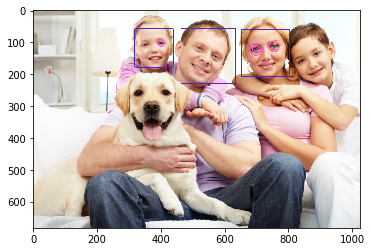

```
Number of faces detected: 1
Number of eyes detected: 2
```

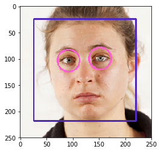

```
Number of faces detected: 1
Number of eyes detected: 2
```

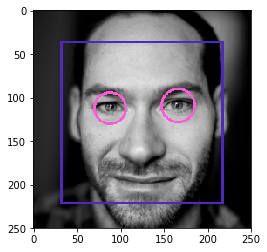

```
Number of faces detected: 1
Number of eyes detected: 2
```

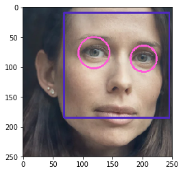

```
Number of faces detected: 2
Number of eyes detected: 0
```

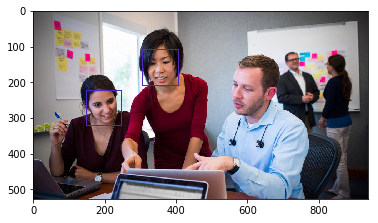

```
Number of faces detected: 6
Number of eyes detected: 7
```

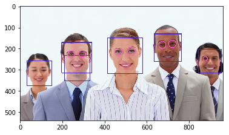

```
Number of faces detected: 2
Number of eyes detected: 0
```

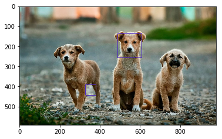

```
Number of faces detected: 2
Number of eyes detected: 0
```

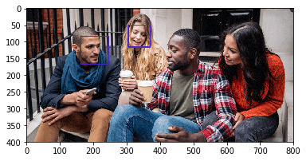

```
Number of faces detected: 1
Number of eyes detected: 2
```

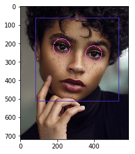

```
Number of faces detected: 1
Number of eyes detected: 2
```

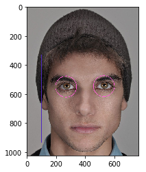

```
Number of faces detected: 1
Number of eyes detected: 2
```

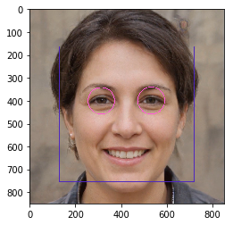

```
Number of faces detected: 1
Number of eyes detected: 0
```

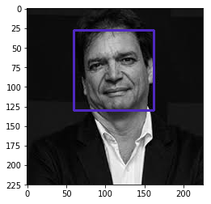

```python
#importing necessary libraries.
import cv2
import numpy as np
from glob import glob
import matplotlib.pyplot as plt
%matplotlib inline


# load filenames for human images
human_files = np.array(glob("human_images/*"))
# extract pre-trained face and eye detectors
face_cascade = cv2.CascadeClassifier('haarcascade_frontalface_alt.xml')
eye_cascade = cv2.CascadeClassifier('haarcascade_eye_tree_eyeglasses.xml')
    # load color (BGR) image
for image in human_files:
    img = cv2.imread(image)

    # convert BGR image to grayscale
    gray = cv2.cvtColor(img, cv2.COLOR_BGR2GRAY)
    # find faces in image
    faces = face_cascade.detectMultiScale(gray)
    eyes = eye_cascade.detectMultiScale(gray)
    # print number of faces and eyes detected in the image
    print('Number of faces detected:', len(faces))
    print('Number of eyes detected:', len(eyes))
    # get bounding box for each detected face and eye
    for (x,y,w,h) in faces:
        # add bounding box to color image
        cv2.rectangle(img,(x,y),(x+w,y+h),(191,40,78),2)
    for (x2,y2,w2,h2) in eyes:
        # add bounding box to color image
        radius = int(round((w2 + h2)*0.25))
        cv2.circle(img,(x2+w2//2,y2+h2//2),radius, (216,91,255), 2)
        # convert BGR image to RGB for plotting
    cv_rgb = cv2.cvtColor(img, cv2.COLOR_BGR2RGB)
        # display the image, along with bounding box
    plt.imshow(cv_rgb)
    plt.show()
```

## 4- Refrences:

1- How to set up your computer to work with the OpenCV library: https://docs.opencv.org/master/df/d65/tutorial_table_of_content_introduction.html  
2- Face Detection in 2 Minutes using OpenCV & Python: https://towardsdatascience.com/face-detection-in-2-minutes-using-opencv-python-90f89d7c0f81  
3- Cascade Classifier: https://docs.opencv.org/master/db/d28/tutorial_cascade_classifier.html